# 統計データ解析I

第7講 練習問題 解答例

Published

June 4, 2025

## 準備

以下で利用する共通パッケージを読み込む．

```r
library(conflicted)  # 関数名の衝突を警告
conflicts_prefer(    # 優先的に使う関数を指定
    dplyr::filter(),
    dplyr::select(),
    dplyr::lag(),
    )
library(tidyverse)
```

## 大数の法則

### 問題

大数の法則の数値実験を行いなさい．

- 歪んだサイコロを例として， n回サイコロを振って標本平均(期待値)を求めたとき， nの値に応じて真の値と標本平均がどのくらい異なるか調べなさい．
- nの値ごとに多数回実験を行い， 標本平均の分布がnの値とともにどのように変化するか調べなさい．

### 解答例

試行(離散分布の標本平均の計算)を定義する．

```r
omega <- 1:6               # サイコロの目 (標本空間．以下では固定)
my_mean <- function(n, p){ # 歪んだサイコロの標本平均を計算する関数
    mean(sample(omega, size = n, prob = p, replace = TRUE))}
```

以下の実験で明示的に変えるものを関数の引数としている．

- `n` はサイコロを振る回数
- `p` は歪み具合

`n,p` ともに `omega` と同じように関数の外側で定義することもできる．

**Tip**

乱数のシード値を指定すれば同じ乱数系列を利用して実験を再現することができる．

```r
set.seed(121212) # 乱数のシード値の指定
```

実験の設定を行う．

```r
(p <- rep(1:2, 3))              # 出現確率の比(奇数1:偶数2)を設定
```

```
[1] 1 2 1 2 1 2
```

```r
(mu <- weighted.mean(omega, p)) # 理論上の平均
```

```
[1] 3.666667
```

```r
roll <- 1:6                     # サイコロの目
probability <- p/sum(p)         # 確率値に変換
```

`n` 毎に図を作る場合は，例えば以下のようにする．

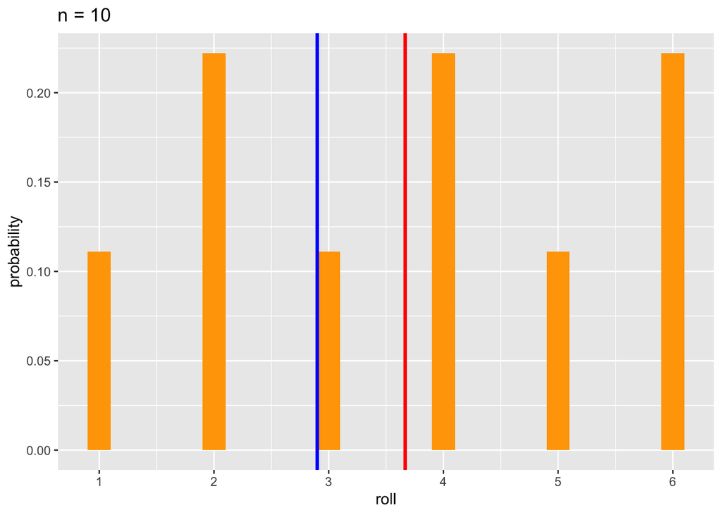

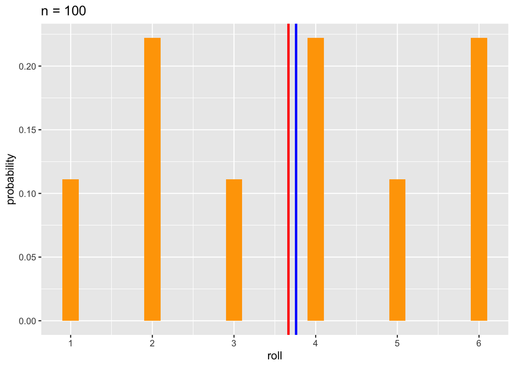

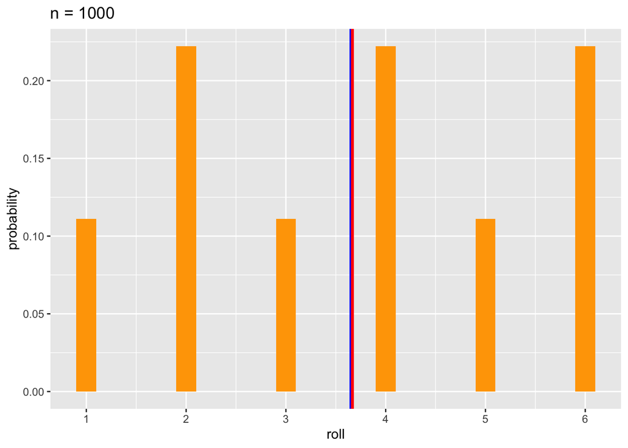

```r
for(n in c(10,100,1000)){ # サンプル数を変えて実験
    xbar <- my_mean(n, p) # 1回実験を行う
    foo <- tibble(roll, probability) |>
        ggplot(aes(x = roll, y = probability)) +
        geom_bar(stat = "identity", fill = "orange", width = 0.2) +
        geom_vline(xintercept = xbar, # 標本平均 (1回の実験による推定値)
                   colour = "blue", linewidth = 1.1) +
        geom_vline(xintercept = mu,   # 真の平均
                   colour = "red", linewidth = 1.1) +
        scale_x_continuous(breaks = roll) +
        labs(title = paste("n =", n))
    print(foo) # ggplot オブジェクトはブロックの中では明示的にprintする必要がある
}
```

多数の `n` と標本平均を1つの図で比較する．

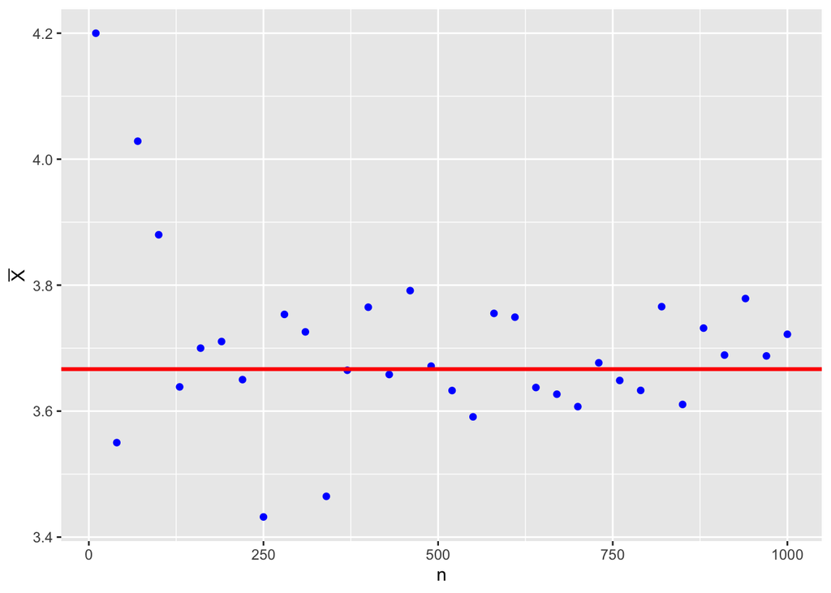

```r
nseq <- seq(10, 1000, by = 30)             # 10から1000まで30おきに調べる
xbars <- sapply(nseq,                      # 各値について以下の関数を計算
                function(x) my_mean(x, p)) # '?sapply'を参照
tibble(n = nseq, xbar = xbars) |>
    ggplot(aes(x = n, y = xbar)) +
    geom_point(colour = "blue") + # n毎の標本平均
    geom_hline(yintercept = mu,   # 真の平均
               colour = "red", linewidth = 1.1) +
    labs(y = expression(bar(X))) # help(expression), help(plotmath) 参照
```

サンプル数の違いによる標本平均の分布を比較する． `n` 毎に図を作る場合は以下のようにすればよい．

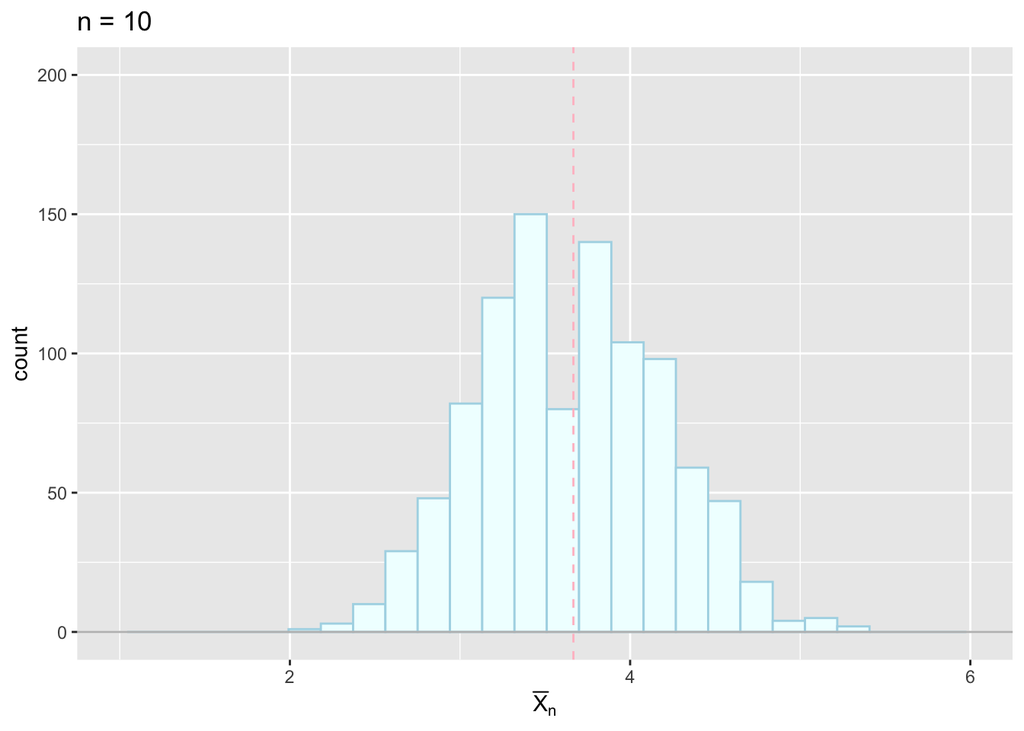

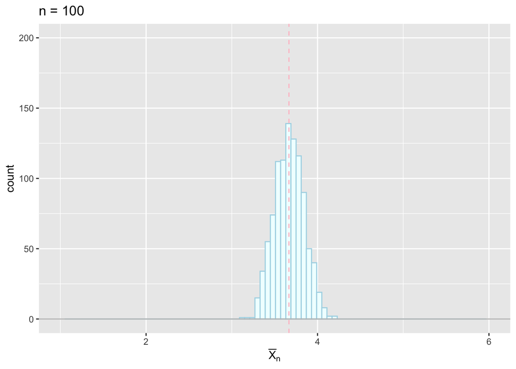

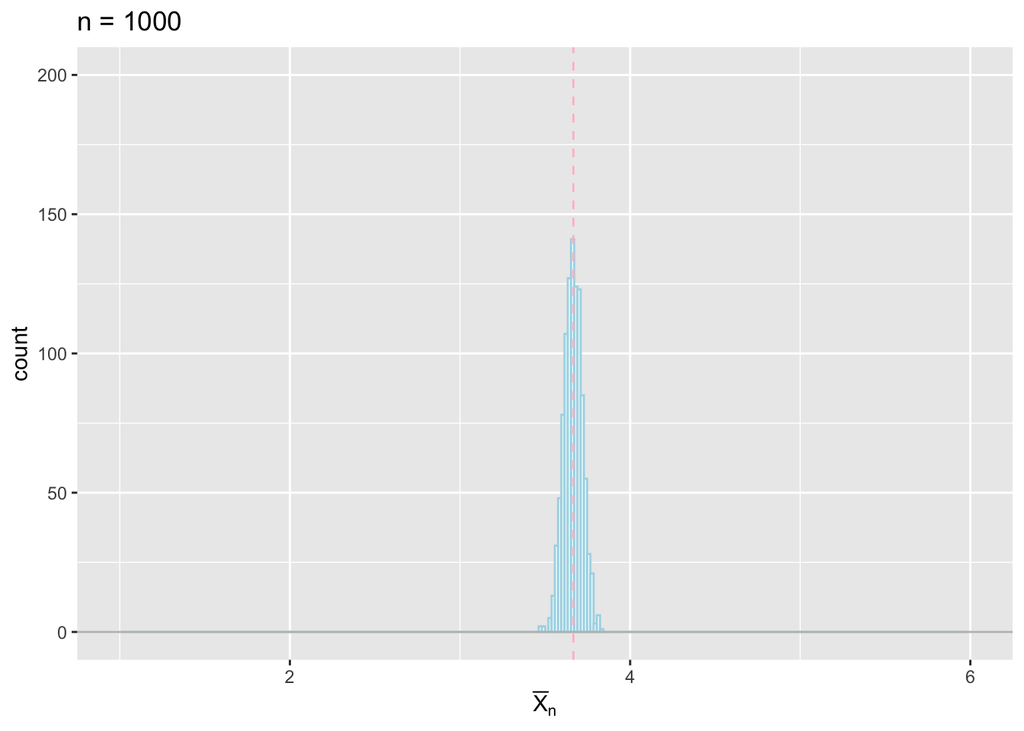

```r
mc <- 1000 # Monte-Carlo実験の回数
for(n in c(10,100,1000)){ # サンプル数を変えて実験
    xbars <- replicate(mc, my_mean(n, p)) # mc回繰り返し
    foo <- tibble(x = xbars) |>
        ggplot(aes(x = x)) +
        geom_histogram(binwidth = 0.6/sqrt(n), # ビンの幅
                       fill ="azure",          # 塗り潰しの色
                       colour = "lightblue") + # 線の色
        geom_vline(xintercept = mu,
                   colour = "pink",       # 線の色
                   linetype = "dashed") + # 線の種類
        geom_hline(yintercept = 0,
                   colour = "grey",
                   linetype = "solid") +
        xlim(1,6) + ylim(0,200) + # 複数の図を同じ領域で描画(適宜調整が必要)
        labs(x = expression(bar(X)[n]),
             title = paste("n =", n))
    print(foo)
}
```

**Note**

警告は `xlim` で指定した範囲の `bin` にはデータが無いため．

多数の `n` と標本平均を1つの図で比較する場合は以下のようにすればよい．

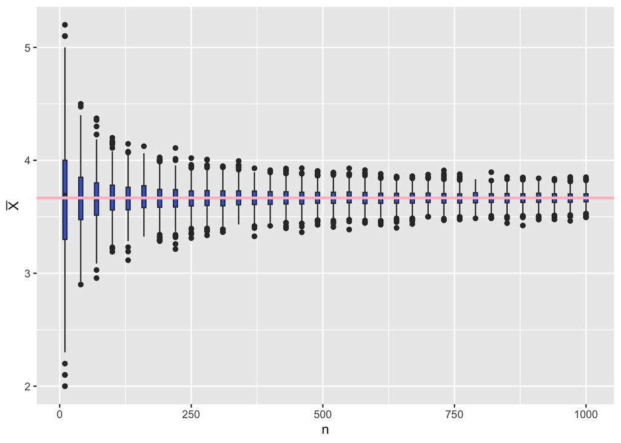

```r
my_data <- tibble(n = NULL, xbar = NULL) # 空のデータフレームを作成
for(n in nseq){ # サンプル数を変えて実験して追加する
    xbars <- replicate(mc, my_mean(n, p))
    my_data <- bind_rows(my_data,
                         tibble(n = rep(n,mc), xbar = xbars))
}
my_data |>
    ggplot(aes(x = n, y = xbar)) +
    geom_boxplot(aes(group = n),       # 標本平均の分
                 fill = "royalblue") +
    geom_hline(yintercept = mu,   # 真の平均
               colour = "pink",
               linewidth = 1.1) +
    labs(x = "n",
         y = expression(bar(X)))
```

統計的性質を見るためには，以下のような実験も考えることができる．

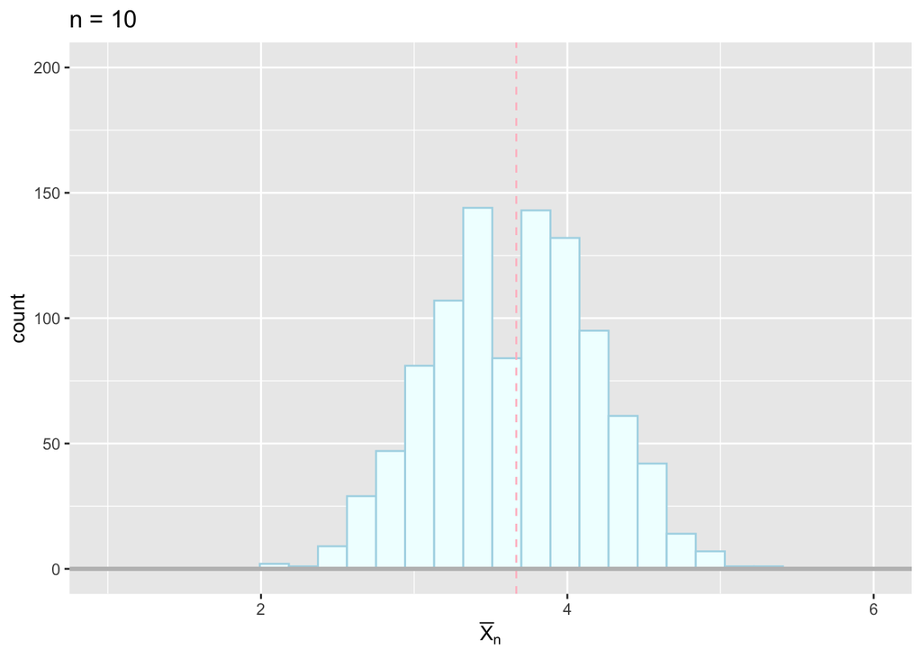

```r
#'
p <- rep(1:2, 3) # 出現確率の比(奇数1:偶数2)
mu <- weighted.mean(omega, p) # 理論上の平均
mc <- 1000 # Monte-Carlo実験の回数
n <- 10 # 標本数
xbars <- replicate(mc, my_mean(n, p))
tibble(x = xbars) |>
    ggplot(aes(x = x)) +
    geom_histogram(binwidth = 0.6/sqrt(n),
                   fill ="azure",
                   colour = "lightblue") +
    geom_vline(xintercept = mu,
               colour = "pink",
               linetype = "dashed") +
    geom_hline(yintercept = 0,
               colour = "grey",
               linewidth = 1.1,
               linetype = "solid") +
    xlim(1,6) + ylim(0,200) +
    labs(x = expression(bar(X)[n]),
         title = paste("n =", n))
```

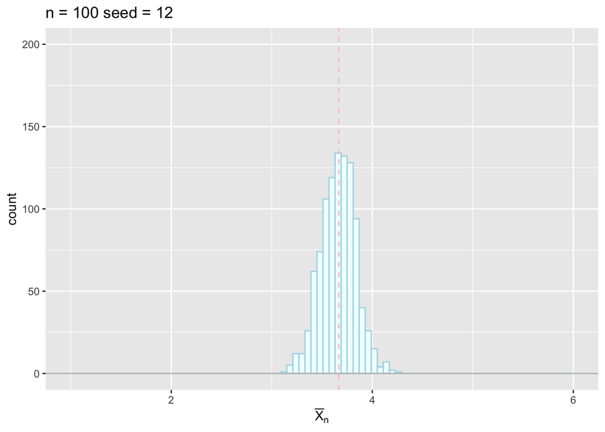

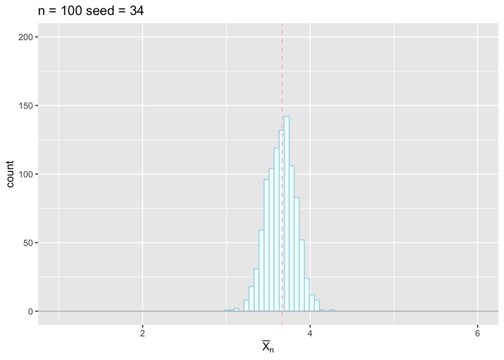

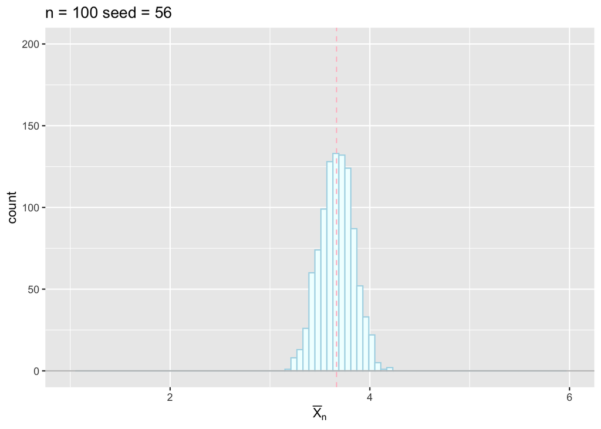

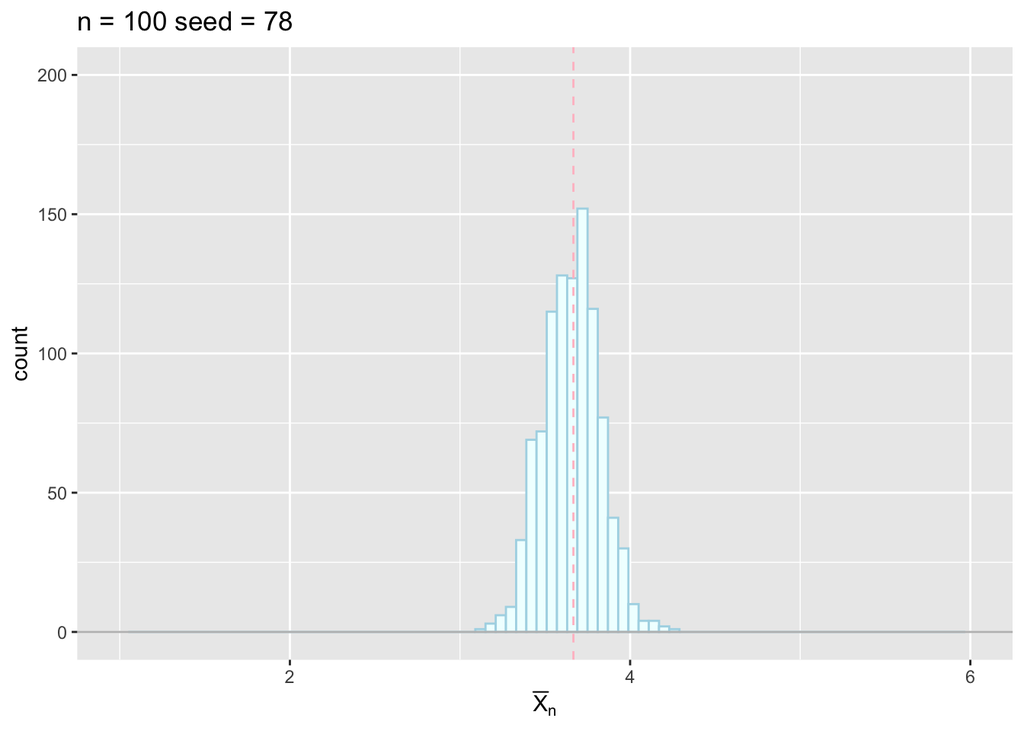

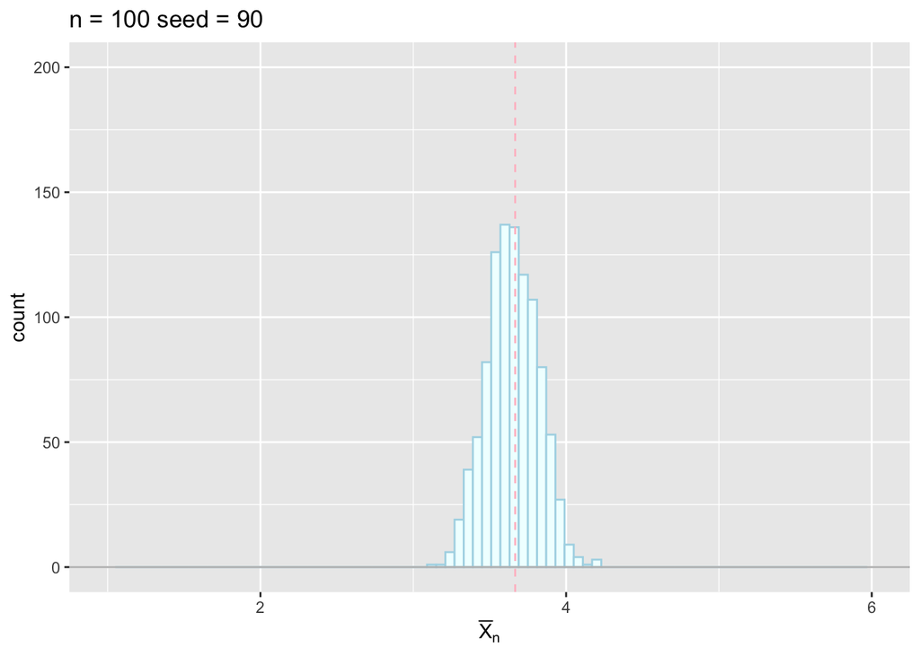

```r
#' 乱数のシードによる違いを比較する．
n <- 100 # 標本数
for(i in c(12,34,56,78,90)){ # シード値を指定
    set.seed(i)
    xbars <- replicate(mc, my_mean(n, p))
    foo <- tibble(x = xbars) |>
        ggplot(aes(x = x)) +
        geom_histogram(binwidth = 0.6/sqrt(n),
                       fill ="azure",
                       colour = "lightblue") +
        geom_vline(xintercept = mu,
                   colour = "pink",
                   linetype = "dashed") +
        geom_hline(yintercept = 0,
                   colour = "grey",
                   linetype = "solid") +
        xlim(1,6) + ylim(0,200) +
        labs(x = expression(bar(X)[n]),
             title = paste("n =", n, "seed =", i))
    print(foo)
}
```

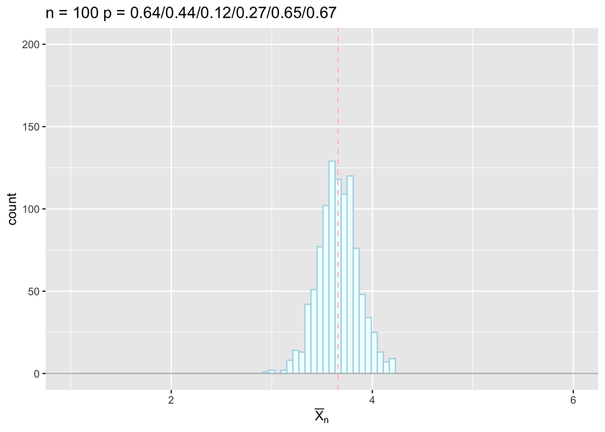

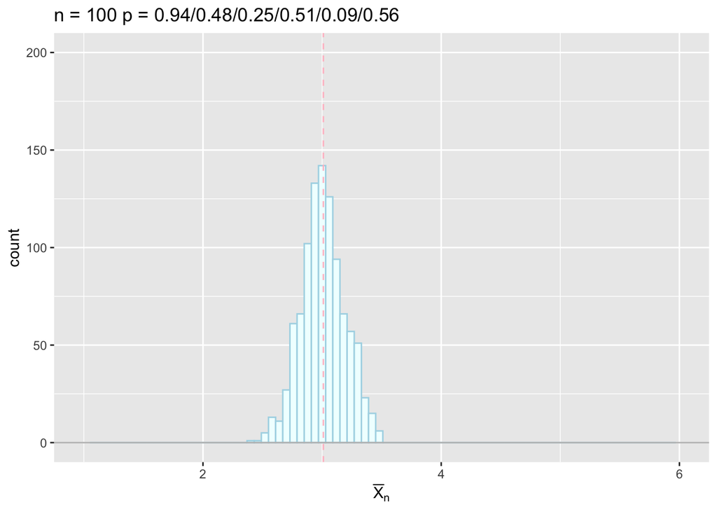

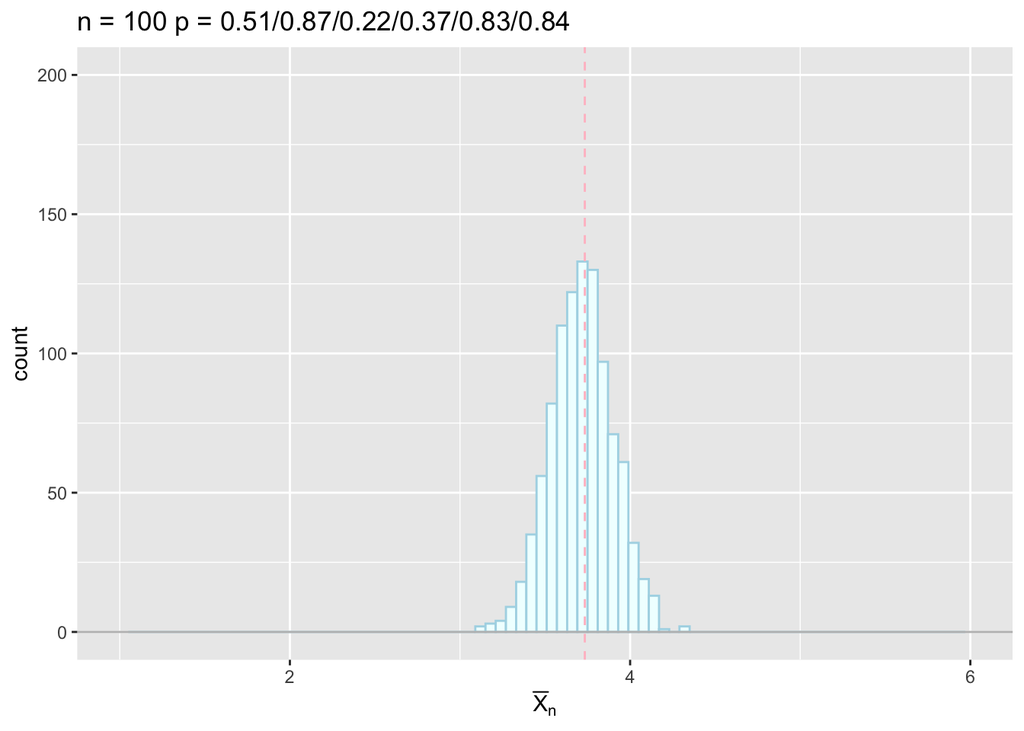

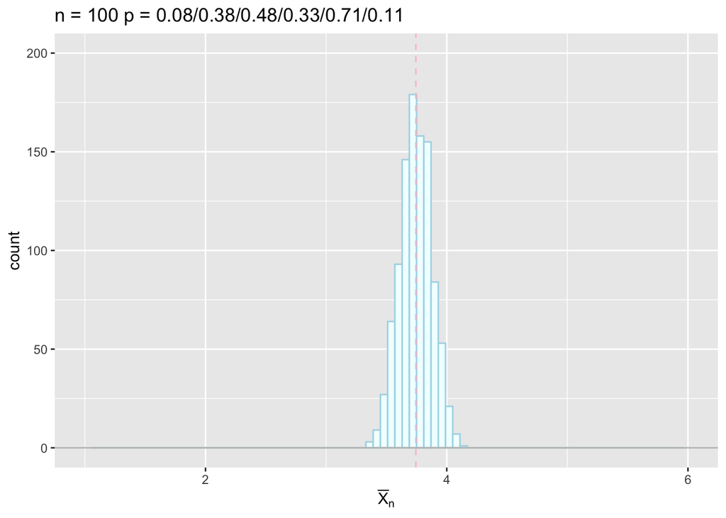

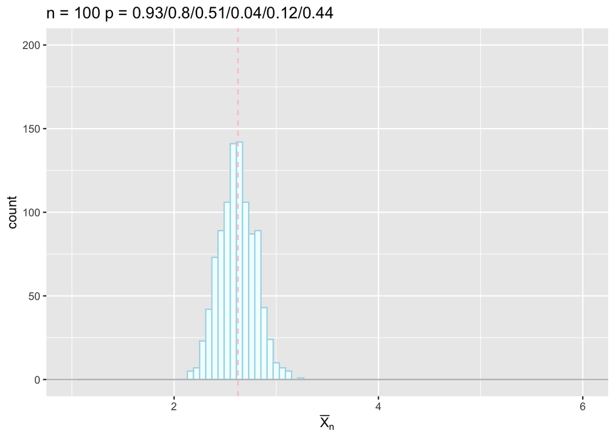

```r
#' 出現確率の違いを比較する．
n <- 100 # 標本数
for(i in 1:5){ # pをランダムに設定して実験
    p <- runif(length(omega)) # 一様乱数で出現確率を設定
    mu <- weighted.mean(omega, p) # 理論上の平均
    xbars <- replicate(mc, my_mean(n, p))
    foo <- tibble(x = xbars) |>
        ggplot(aes(x = x)) +
        geom_histogram(binwidth = 0.6/sqrt(n),
                       fill ="azure",
                       colour = "lightblue") +
        geom_vline(xintercept = mu,
                   colour = "pink",
                   linetype = "dashed") +
        geom_hline(yintercept = 0,
                   colour = "grey",
                   linetype = "solid") +
        xlim(1,6) + ylim(0,200) +
        labs(x = expression(bar(X)[n]),
             title = paste("n =", n, "p =", paste(round(p, 2), collapse = "/")))
    print(foo)
}
```

## 中心極限定理

### 問題

中心極限定理の数値実験を行いなさい．

- 歪んだサイコロを例として， n回サイコロを振って標本平均(期待値)を求めたとき， nが大きければ正規化した値は標準正規分布に従うことを確認しなさい．
- 確率(歪み具合)が異なっても， 上記の性質は変わらないことを確認しなさい．

### 解答例

試行(離散分布の標本平均の計算)を定義する．

```r
omega <- 1:6 # 以下サイコロの場合で実験
my_mean <- function(n, p){ # 標本平均を計算する関数
    mean(sample(omega, size = n, prob = p, replace=TRUE))}
mc <- 10000 # Monte-Carlo実験の繰り返し回数(大数の法則より多めに実験する)
```

サンプル数の違いによる分布の比較する．

```r
p <- rep(1:2, 3) # 出現確率の比(奇数1:偶数2) (9で割らなくても大丈夫)
(mu <- weighted.mean(omega, p)) # 理論上の平均
```

```
[1] 3.666667
```

```r
(sigma <- sqrt( # 理論上の標準偏差(分散の平方根)
     weighted.mean(omega^2,p)-mu^2))
```

```
[1] 1.699673
```

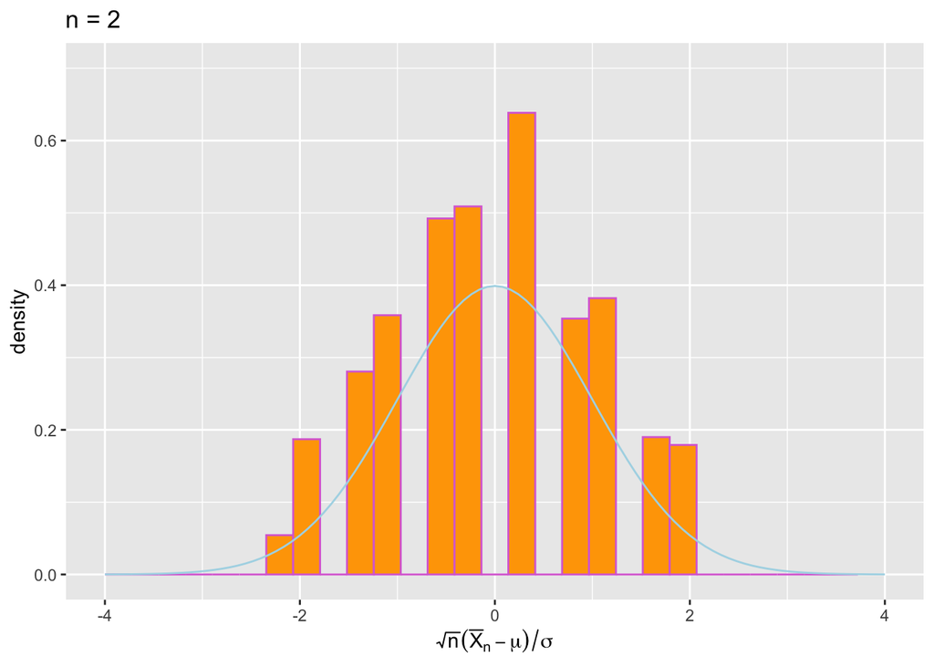

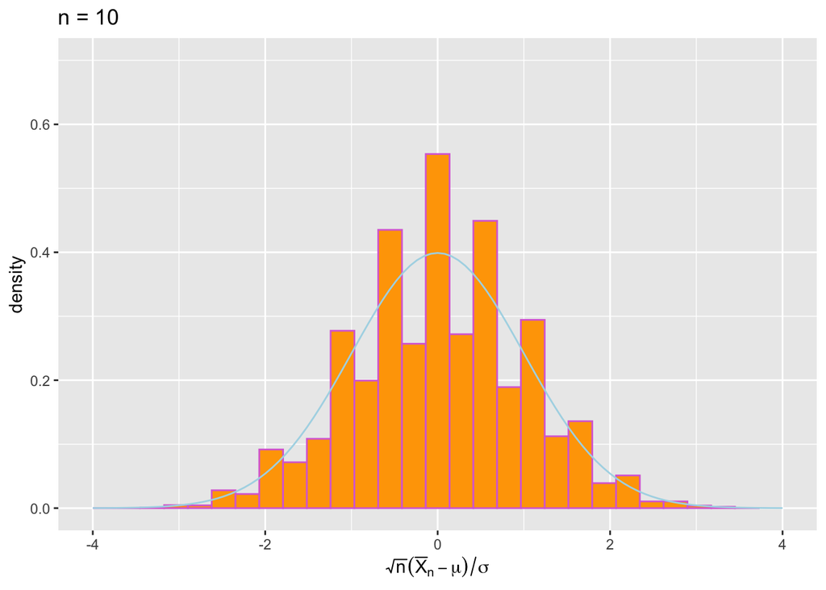

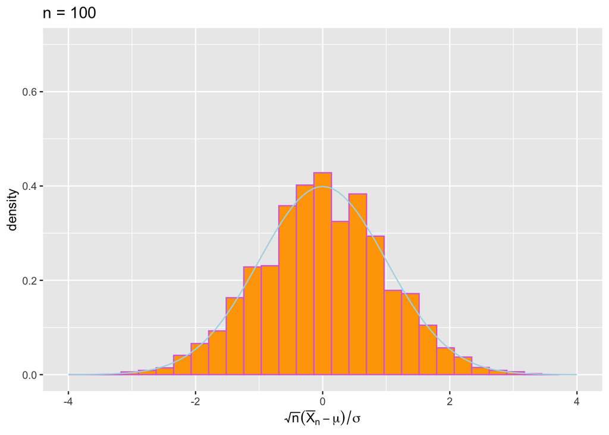

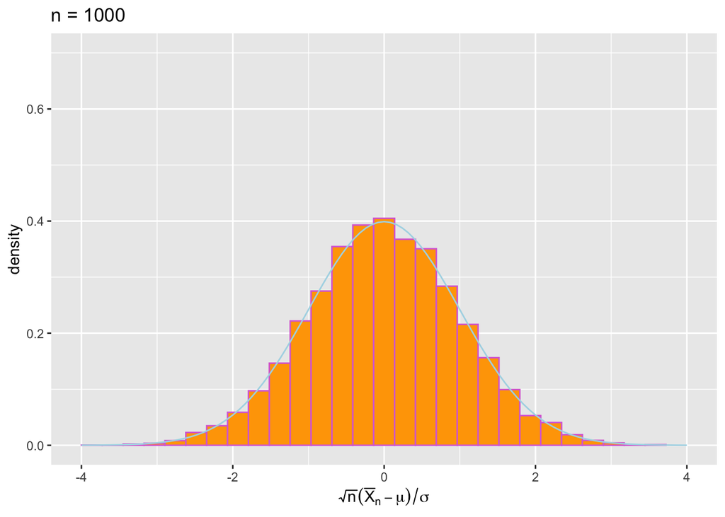

```r
for(n in c(2,10,100,1000)){ # サンプル数を変えて実験
    xbars <- replicate(mc, my_mean(n, p))
    foo <- tibble(x = sqrt(n)*(xbars - mu)/sigma) |>
        ggplot(aes(x = x)) +
        geom_histogram(aes(y = after_stat(density)), # 密度で表示
                       bins = 30,                    # ビンの数を指定
                       fill ="orange",
                       colour = "orchid") +
        geom_function(fun = dnorm, # 理論曲線(標準正規分布)と比較
                      colour = "lightblue") +
        xlim(-4,4) + ylim(0,0.7) + # 比較のため表示領域を限定する
        labs(x = expression(sqrt(n)*(bar(X)[n]-mu)/sigma),
             title = paste("n =", n))
    print(foo)
}
```

出現確率の違いによる分布の比較する．

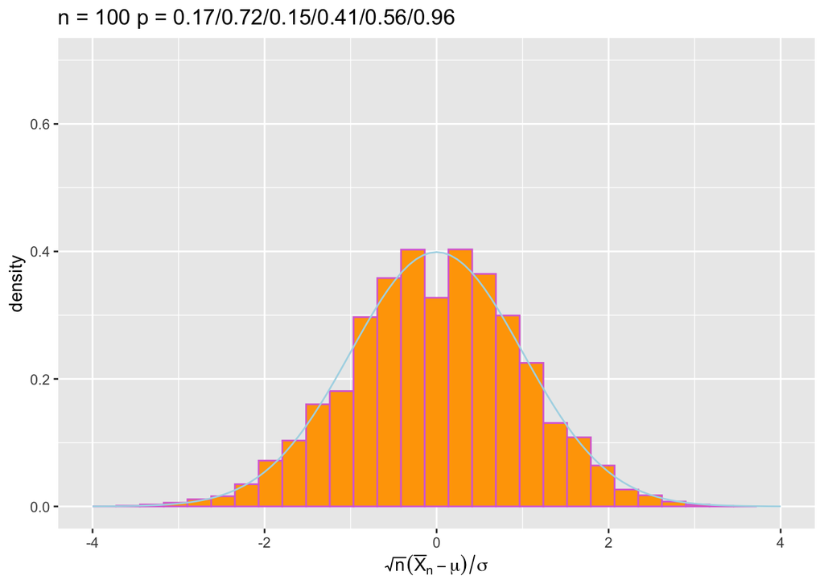

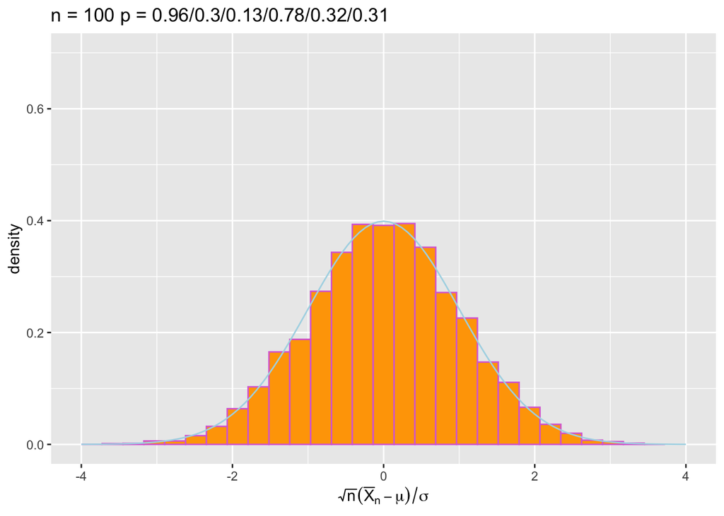

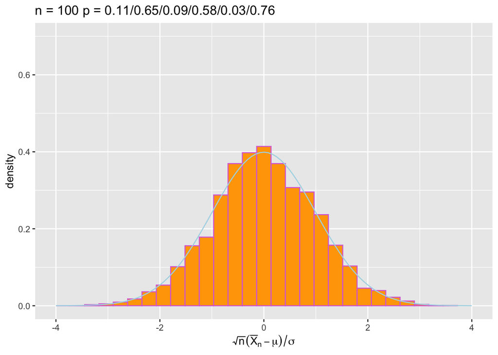

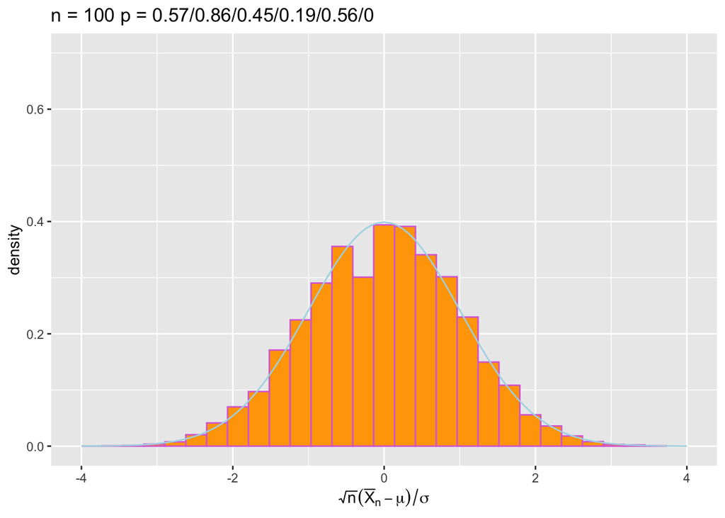

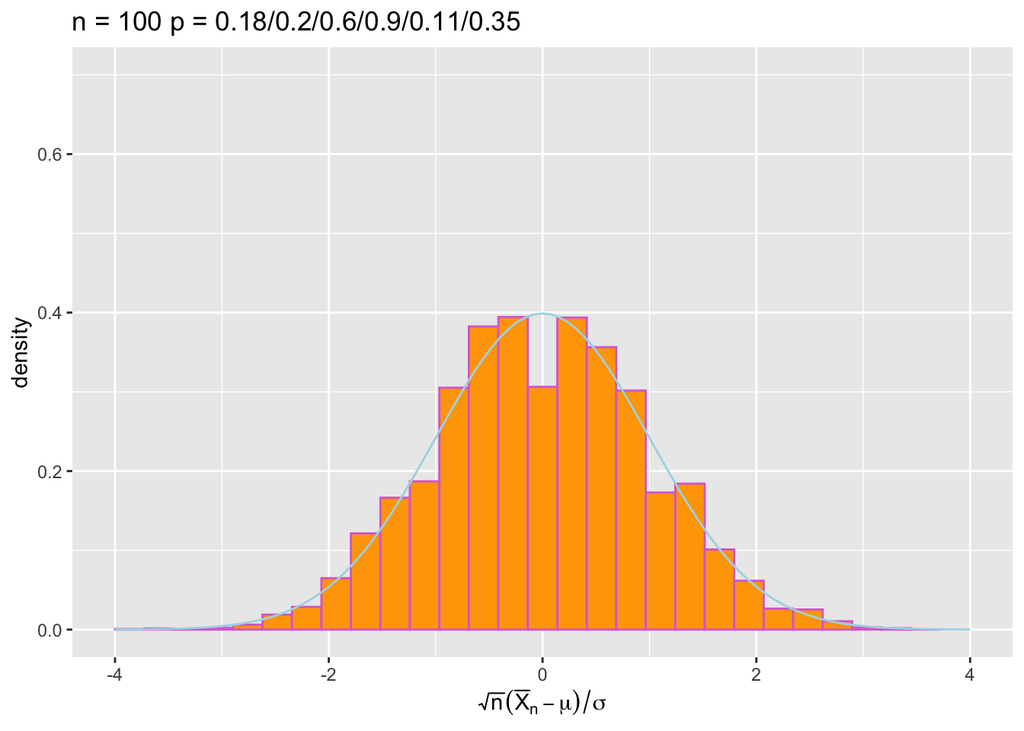

```r
n <- 100 # 標本数 (いろいろ変えて実験せよ．nが小さいとpの影響が大きい)
for(i in 1:5){ # pをランダムに設定して実験
    p <- runif(length(omega)) # 一様乱数で出現確率を設定
    mu <- weighted.mean(omega, p) # 理論上の平均
    sigma <- sqrt( # 理論上の標準偏差(分散の平方根)
        weighted.mean(omega^2,p)-mu^2)
    xbars <- replicate(mc, my_mean(n,p))
    foo <- tibble(x = sqrt(n)*(xbars - mu)/sigma) |>
        ggplot(aes(x = x)) +
        geom_histogram(aes(y = after_stat(density)),
                       bins = 30,
                       fill ="orange",
                       colour = "orchid") +
        geom_function(fun = dnorm,
                      colour = "lightblue") +
        xlim(-4,4) + ylim(0,0.7) +
        labs(x = expression(sqrt(n)*(bar(X)[n]-mu)/sigma),
             title = paste("n =", n, "p =", paste(round(p, 2), collapse = "/")))
    print(foo)
}
```